# Reproducible Research Project 2: NOAA Storm Data Analysis

# Synopsis

In this project I will analyze NOAA storm data covering meteorological events taking place between 1950 and November 2011. Two questions I will attempt to address are: 1. Across the United States, which types of events are most harmful with respect to population health? 2. Across the United States, which types of events have the greatest economic consequences?

In summary, the answer to first question is that the most harmful event is tornado with respect to human fatalities (5,633 people across the data collection years) and injuries (91,346 people across the data collection years). Additionally, hail has the greatest negative economic impact on crops while tornados have the most significant negative economic effect on property.

# Data Processing

### General Strategy:

Data for inititial analysis and plotting will be pulled from a 10K record sample (~6MB) of the entire dataset (~536MB). Once basic analysis, plotting and document layout are completed, the “large” switch will be set to TRUE to enable loading of the entirety of NOAA’s storm data file (~536MB). This is a cacheing strategy borrowed from previous data analysis assignments. This may prove to be unsuitable for knitr document creation, but, at the very least, it facilitated prototyping all code in a standard R source code module.

### Load Libraries

```r
library( ggplot2 )
require( gridExtra )
```

### Set Environment Variables

```r
large <- TRUE
download <- FALSE
```

### Get Data

```r
## Condidtional download of the data
if ( download ) {
    url <- "https://d396qusza40orc.cloudfront.net/repdata%2Fdata%2FStormData.csv.bz2"
    download.file( url, "../data/StormDF.csv.bz2" )
}
```

### Load Data

```r
# Conditional dataset size: use full, refreshed, data sets...
if ( large ) {

    print( "Using FULL version of stormData..." )
    if ( download ) {
        stormData <- read.csv( bzfile( "../data/StormDF.csv.bz2" ) )
    } else {
        stormData <- read.csv( "../data/repdata-data-StormData.csv" )
    }

} else { # ...or smaller samples

    print( "Using SAMPLED version of stormData..." )
    stormData <- read.csv( "../data/stormDataSample.csv" )
}
```

```
## [1] "Using FULL version of stormData..."
```

### Clean Data

```r
## remove superfluous columns (this matters w/ large datasets!)
## deal w/ borked strings
## impute missing values, if necessary
```

### Analyze Data: Human Fatalities & Injuries

```r
fatalities <- aggregate( stormData[ "FATALITIES" ], by = stormData[ c( "EVTYPE" ) ], FUN = sum, na.rm = TRUE )
orderedFatalities <- fatalities[ order( -fatalities$FATALITIES ), ]
#substitute "top 10"
orderedFatalities <- head( orderedFatalities, 10 )
#orderedFatalities <- orderedFatalities[ which( orderedFatalities$FATALITIES > 0 ), ]
print( orderedFatalities )
```

```
##             EVTYPE FATALITIES
## 834        TORNADO       5633
## 130 EXCESSIVE HEAT       1903
## 153    FLASH FLOOD        978
## 275           HEAT        937
## 464      LIGHTNING        816
## 856      TSTM WIND        504
## 170          FLOOD        470
## 585    RIP CURRENT        368
## 359      HIGH WIND        248
## 19       AVALANCHE        224
```

```r
injuries <- aggregate( stormData[ "INJURIES" ], by = stormData[ c( "EVTYPE" ) ], FUN = sum, na.rm = TRUE )
orderedInjuries <- injuries[ order( -injuries$INJURIES ), ]
#substitute "top 10"
orderedInjuries <- head( orderedInjuries, 10 )
#orderedInjuries <- orderedInjuries[ which( orderedInjuries$INJURIES > 0 ), ]
print( orderedInjuries )
```

```
##                EVTYPE INJURIES
## 834           TORNADO    91346
## 856         TSTM WIND     6957
## 170             FLOOD     6789
## 130    EXCESSIVE HEAT     6525
## 464         LIGHTNING     5230
## 275              HEAT     2100
## 427         ICE STORM     1975
## 153       FLASH FLOOD     1777
## 760 THUNDERSTORM WIND     1488
## 244              HAIL     1361
```

### Analyze Data: Property & Crop Damages

```r
cropDamages <- aggregate( stormData[ "CROPDMG" ], by = stormData[ c( "EVTYPE" ) ], FUN = sum, na.rm = TRUE )
orderedCropDamages <- cropDamages[ order( -cropDamages$CROPDMG ), ]
orderedCropDamages <- head( orderedCropDamages, 10 )
print( orderedCropDamages )
```

```
##                 EVTYPE   CROPDMG
## 244               HAIL 579596.28
## 153        FLASH FLOOD 179200.46
## 170              FLOOD 168037.88
## 856          TSTM WIND 109202.60
## 834            TORNADO 100018.52
## 760  THUNDERSTORM WIND  66791.45
## 95             DROUGHT  33898.62
## 786 THUNDERSTORM WINDS  18684.93
## 359          HIGH WIND  17283.21
## 290         HEAVY RAIN  11122.80
```

```r
propertyDamages <- aggregate( stormData[ "PROPDMG" ], by = stormData[ c( "EVTYPE" ) ], FUN = sum, na.rm = TRUE )
orderedPropertyDamages <- propertyDamages[ order( -propertyDamages$PROPDMG ), ]
orderedPropertyDamages <- head( orderedPropertyDamages, 10 )
print( orderedPropertyDamages )
```

```
##                 EVTYPE   PROPDMG
## 834            TORNADO 3212258.2
## 153        FLASH FLOOD 1420124.6
## 856          TSTM WIND 1335965.6
## 170              FLOOD  899938.5
## 760  THUNDERSTORM WIND  876844.2
## 244               HAIL  688693.4
## 464          LIGHTNING  603351.8
## 786 THUNDERSTORM WINDS  446293.2
## 359          HIGH WIND  324731.6
## 972       WINTER STORM  132720.6
```

# Results

### Results: Human Fatalities & Injuries

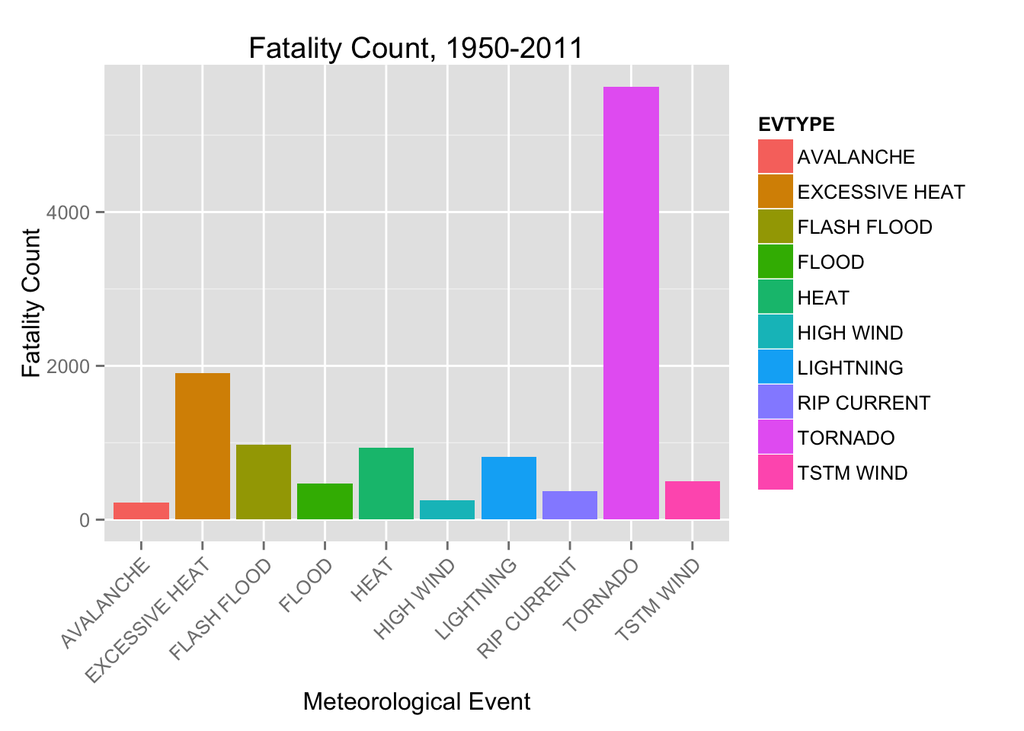

```r
ggplot( data = orderedFatalities, aes( x = orderedFatalities$EVTYPE, y = orderedFatalities$FATALITIES, fill = EVTYPE ) ) +
    geom_bar( stat = "identity" ) +
    theme( axis.text.x = element_text( angle = 45, hjust = 1 ) ) +
    xlab( "Meteorological Event" ) +
    ylab( "Fatality Count" ) +
    ggtitle( "Fatality Count, 1950-2011" )
```

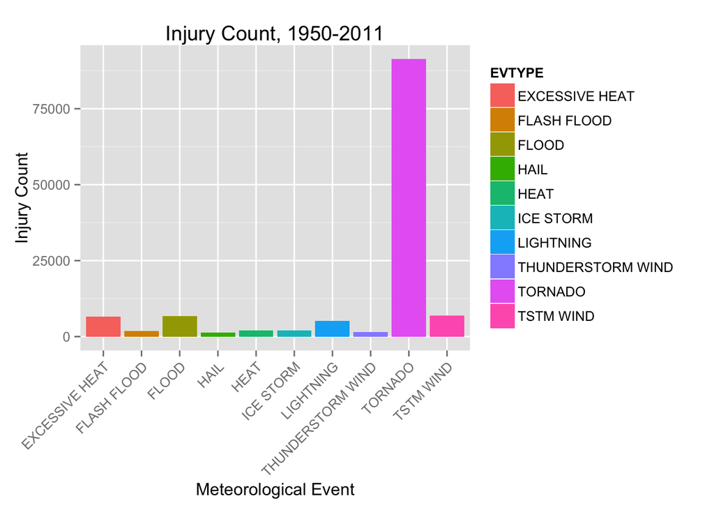

```r
ggplot( orderedInjuries, aes( x = EVTYPE, y = INJURIES, fill = EVTYPE ) ) +
    geom_bar( stat="identity", position = "dodge" ) +
    labs( x = "Meteorological Event", y = "Injury Count" ) +
    labs( title = "Injury Count, 1950-2011" ) +
    theme( axis.text.x = element_text( angle = 45, vjust = 1, hjust=1 ) )
```

### Results: Property & Crop Damages

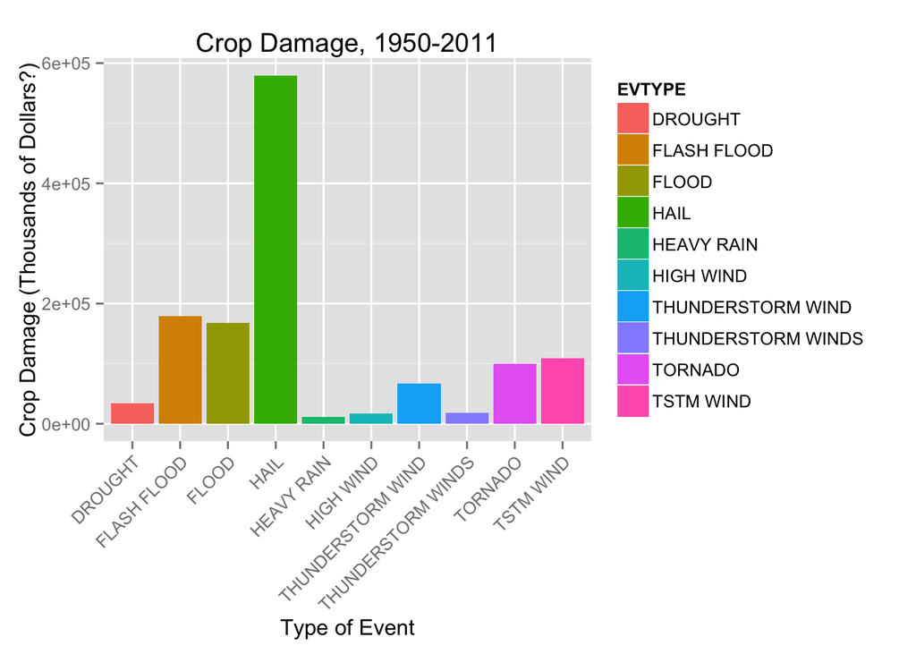

```r
cropsPlot <- ggplot( orderedCropDamages, aes( x = EVTYPE, y = CROPDMG, fill = EVTYPE ) ) +
    geom_bar( stat="identity", position = "dodge" ) +
    labs( x = "Type of Event", y = "Crop Damage (Thousands of Dollars?)" ) +
    labs( title = "Crop Damage, 1950-2011" ) +
    theme( axis.text.x = element_text( angle = 45, vjust = 1, hjust=1 ) )
print( cropsPlot )
```

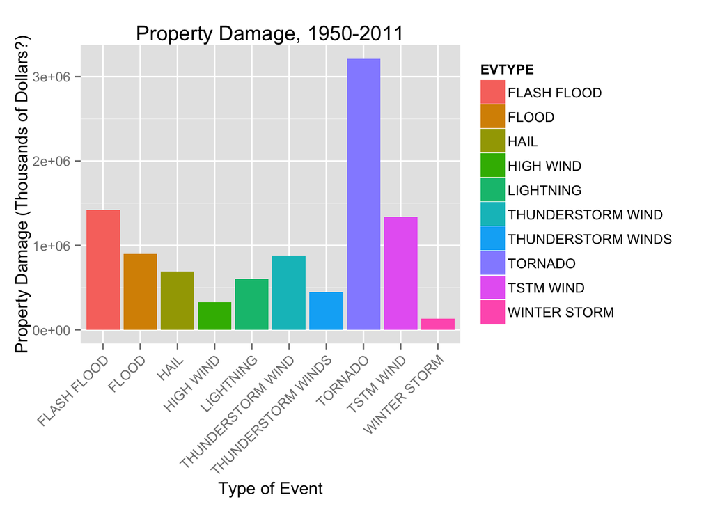

```r
propertyPlot <- ggplot( orderedPropertyDamages, aes( x = EVTYPE, y = PROPDMG, fill = EVTYPE ) ) +
    geom_bar( stat="identity", position = "dodge" ) +
    labs( x = "Type of Event", y = "Property Damage (Thousands of Dollars?)" ) +
    labs( title = "Property Damage, 1950-2011" ) +
    theme( axis.text.x = element_text( angle = 45, vjust = 1, hjust=1 ) )
print( propertyPlot )
```

```r
#can't get good leayout w/o cxrushing...
#grid.arrange( propertyPlot, cropsPlot, heights=3:3, widths=3:3 )
```